# Forest Fires in Portugal - What Are The Causes?

Practical Assignment of Data Mining I

By Robson Teixeira, Eduardo Rodrigues and Claudio Rocha

M:CC – FCUP, 10/01/2021

# 1 Introduction

# 2 Problem Definition

Forest fires are a very important issue that negatively affects climate change. Typically, the causes of forest fires are those oversights, accidents and negligence committed by individuals, intentional acts and natural causes. The latter is the root cause for only a minority of the fires.

Their harmful impacts and effects on ecosystems can be major ones. Among them, we can mention the disappearance of native species, the increase in levels of carbon dioxide in the atmosphere, earth’s nutrients destroyed by the ashes, and the massive loss of wildlife.

Data mining techniques can help in the prediction of the cause of the fire and, thus, better support the decision of taking preventive measures in order to avoid tragedy. In effect, this can play a major role in resource allocation, mitigation and recovery efforts.

# 3 Forest Fire Dataset

The Institute for Nature Conservation and Forests ([ICNF](http://www.icnf.pt/portal/florestas/dfci/estatisticas)) is the governmental body responsible for the nature and forest policies, including the management of protected areas and state managed national, municipal, and communal forests of mainland Portugal. The ICNF has been maintained a database with data of all forest fires that occurred in Portugal over several years. The dataset used in this study is a subset extracted from this database regarding the fires that occurred over 2015. It consist of **7511** records of fires and for each one, there is relevant information such as the GPS coordinates (latitude and longitude) where occur the fire, the date and time of fire alert, the date and time of the first intervention, and the date and time of fire extinction, besides the origin of the ignition, the affected area, and the cause type. The table 3.1 describes all variables contained in `Forest Fires` dataset:

Table (#tab:variables): List of variables in `Forest Fires` dataset.

| Variable | Type | Description |  |
| --- | --- | --- | --- |
| id | integer | id number |  |
| region | character | region name |  |
| district | character | district name |  |
| municipality | character | municipality name |  |
| parish | character | parish name |  |
| lat | character | latitude value |  |
| lon | character | longitude value |  |
| origin | character | how the fire started |  |
| alert_date | character | date when fire started |  |
| alert_hour | character | alert hour |  |
| extinction_date | character | date of the end of fire |  |
| extinction hour | character | hour of the end of fire |  |
| firstInterv_date | character | date of intervention |  |
| firstInterv_hour | character | hour of intervention |  |
| alert_source | logical | alert source |  |
| village_area | numeric | village area affected |  |
| vegetation_area | numeric | vegetation area affected |  |
| farming_area | numeric | farming area affected |  |
| village_veget_area | numeric | total village+veget affected |  |
| total_area | numeric | total area affected |  |
| cause_type | character | cause of the fire |  |

Table (#tab:cause_type): Classifications of causes of forest fires.

[output not shown]

A glimpse of the structure of the `Forest Fires` dataset is provided below:

Table 3: (#tab:glimpse_data) A glimpse the structure of the dataset.

```
## Rows: 7,511
## Columns: 21
## $ id                 <int> 1, 2, 3, 4, 5, 6, 7, 8, 9, 10, 11, 12, 13, 14, 1...
## $ region             <chr> "Entre Douro e Minho", "Entre Douro e Minho", "T...
## $ district           <chr> "Viana do Castelo", "Porto", "Vila Real", "Vila ...
## $ municipality       <chr> "Ponte de Lima", "Marco de Canaveses", "Boticas"...
## $ parish             <chr> "Serdedelo", "Vila Boa de Quires", "Cerdedo", "G...
## $ lat                <chr> "41:44:48.5663999999878''", "41:12:58.4280000000...
## $ lon                <chr> "8:31:12.3276000000027''", "8:12:28.378800000002...
## $ origin             <chr> "fire", "fire", "fire", "firepit", "firepit", "f...
## $ alert_date         <chr> "2015-03-24", "2015-03-24", "2015-03-24", "2015-...
## $ alert_hour         <chr> "17:01:00", "17:10:00", "21:40:00", "16:00:00", ...
## $ extinction_date    <chr> "2015-03-24", "2015-03-24", "2015-03-25", "2015-...
## $ extinction_hour    <chr> "18:09:00", "18:47:00", "05:45:00", "17:00:00", ...
## $ firstInterv_date   <chr> "2015-03-24", "2015-03-24", "2015-03-24", "2015-...
## $ firstInterv_hour   <chr> "17:10:00", "17:16:00", "22:00:00", "16:14:00", ...
## $ alert_source       <lgl> NA, NA, NA, NA, NA, NA, NA, NA, NA, NA, NA, NA, ...
## $ village_area       <dbl> 2.50, 0.00, 0.50, 0.00, 0.10, 0.00, 0.35, 0.50, ...
## $ vegetation_area    <dbl> 0.000, 1.350, 38.000, 0.010, 0.000, 0.100, 14.82...
## $ farming_area       <dbl> 0.0000, 0.0000, 0.0000, 0.0000, 0.0000, 0.0000, ...
## $ village_veget_area <dbl> 2.500, 1.350, 38.500, 0.010, 0.100, 0.100, 15.17...
## $ total_area         <dbl> 2.5000, 1.3500, 38.5000, 0.0100, 0.1000, 0.1000,...
## $ cause_type         <chr> "negligent", "negligent", "negligent", "negligen...
```

A summary for each variable present in dataset is provided below. The metrics displayed are: quantity and percentage of zeros, quantity and quantity and percentage of NA’s, data type and quantity of unique values.

Table 4: (#tab:summary_data) A summary of variables of the dataset.

```
##              variable q_zeros p_zeros q_na   p_na q_inf p_inf      type unique
## 1                  id       0    0.00    0   0.00     0     0   integer   7511
## 2              region       0    0.00  501   6.67     0     0 character     10
## 3            district       0    0.00    0   0.00     0     0 character     19
## 4        municipality       0    0.00    0   0.00     0     0 character    297
## 5              parish       0    0.00    0   0.00     0     0 character   2270
## 6                 lat       0    0.00    0   0.00     0     0 character   5858
## 7                 lon       0    0.00    0   0.00     0     0 character   5867
## 8              origin       0    0.00    0   0.00     0     0 character      5
## 9          alert_date       0    0.00    0   0.00     0     0 character    317
## 10         alert_hour       0    0.00    0   0.00     0     0 character   1312
## 11    extinction_date       0    0.00    9   0.12     0     0 character    319
## 12    extinction_hour       0    0.00    9   0.12     0     0 character   1201
## 13   firstInterv_date       0    0.00  214   2.85     0     0 character    318
## 14   firstInterv_hour       0    0.00  215   2.86     0     0 character   1202
## 15       alert_source       0    0.00 7511 100.00     0     0   logical      0
## 16       village_area    5349   71.22    0   0.00     0     0   numeric    591
## 17    vegetation_area    2648   35.25    0   0.00     0     0   numeric   1052
## 18       farming_area    5976   79.56    0   0.00     0     0   numeric    650
## 19 village_veget_area    1413   18.81    0   0.00     0     0   numeric   1377
## 20         total_area       8    0.11    0   0.00     0     0   numeric   1781
## 21         cause_type       0    0.00    0   0.00     0     0 character      4
```

A sample the first observations is provided below:

| id | region | district | municipality | parish | lat | lon | origin | alert_date | alert_hour | extinction_date | extinction_hour | firstInterv_date | firstInterv_hour | alert_source | village_area | vegetation_area | farming_area | village_veget_area | total_area | cause_type |
| --- | --- | --- | --- | --- | --- | --- | --- | --- | --- | --- | --- | --- | --- | --- | --- | --- | --- | --- | --- | --- |
| 1 | Entre Douro e Minho | Viana do Castelo | Ponte de Lima | Serdedelo | 41:44:48.5663999999878'' | 8:31:12.3276000000027'' | fire | 2015-03-24 | 17:01:00 | 2015-03-24 | 18:09:00 | 2015-03-24 | 17:10:00 | NA | 2.5 | 0.00 | 0 | 2.50 | 2.50 | negligent |
| 2 | Entre Douro e Minho | Porto | Marco de Canaveses | Vila Boa de Quires | 41:12:58.4280000000109'' | 8:12:28.3788000000025'' | fire | 2015-03-24 | 17:10:00 | 2015-03-24 | 18:47:00 | 2015-03-24 | 17:16:00 | NA | 0.0 | 1.35 | 0 | 1.35 | 1.35 | negligent |
| 3 | Trás-os-Montes | Vila Real | Boticas | Cerdedo | 41:38:07 | 07:54:43 | fire | 2015-03-24 | 21:40:00 | 2015-03-25 | 05:45:00 | 2015-03-24 | 22:00:00 | NA | 0.5 | 38.00 | 0 | 38.50 | 38.50 | negligent |
| 4 | Trás-os-Montes | Vila Real | Montalegre | Gralhas | 41:51:4.15079999998738'' | 7:42:11.7215999999988'' | firepit | 2015-03-25 | 16:00:00 | 2015-03-25 | 17:00:00 | 2015-03-25 | 16:14:00 | NA | 0.0 | 0.01 | 0 | 0.01 | 0.01 | negligent |
| 5 | Trás-os-Montes | Vila Real | Valpaços | Algeriz | 41:35:23 | 07:24:14 | firepit | 2015-03-12 | 17:20:00 | 2015-03-12 | 18:30:00 | 2015-03-12 | 17:40:00 | NA | 0.1 | 0.00 | 0 | 0.10 | 0.10 | rekindling |
| 6 | Entre Douro e Minho | Vila Real | Mondim de Basto | Ermelo | 41:21:02 | 07:54:57 | firepit | 2015-03-13 | 14:48:00 | 2015-03-13 | 16:27:00 | 2015-03-13 | 15:18:00 | NA | 0.0 | 0.10 | 0 | 0.10 | 0.10 | negligent |

# 4 Data Preparation

Data preparation consists of the process of cleaning and transforming raw data in a form that can be used by machine learning algorithms. Next sections, we exploit the `Forest Fires` dataset in order to perform the steps of cleaning a transforming, when need.

## 4.1 Data Cleaning

### Latitude and Longitude

The `Forest Fires` dataset store the latitude and longitude of the place where occurred the fire into variables `lat` e `lon` respectively. These values are in format of *DegreesºMinutes’Seconds"* and for the reason contain special characters `º`, `'`, `:` and `"`. Besides, there are wrong values into variables as dates between the coordinates and values with scientific notation `E-12`, `E-11` and `E-02`. A sample of these inconsistencies is provided in the tables below:

| lat | lon |
| --- | --- |
| 41º41'25.821599999997'' | 8º20'37.446000000002'' |

| lat | lon |
| --- | --- |
| 1900-01-01 14:19:38 | 07:30:27 |

| lat | lon |
| --- | --- |
| 38:36:5.11590769747272E-12 | 8:35:49.9999999999972 |

A cleaning and transformation steps were perfomed on `lat` and `lon` variables to remove the special caracters and scientific notation. For the values wrongs where there is a date among the coordinates, it was performed an data imputation based on another observations that has the same `region`, `district`, `municipality` and `parish`. After the cleaning steps, the values were transformated from GPS coordinates to decimals coordinates in order to be able retrieve historical data from nearest weather stations using the [RNOAA](http://spatialecology.weebly.com/r-code--data/34) package

The data imputation and transformation generated 8 NA’s in `lat` and `lon` variables for parishes listed below:

| region | district | municipality | parish | lat | lon |
| --- | --- | --- | --- | --- | --- |
| Alentejo | Évora | Mora | Cabeção | NA | NA |
| Alentejo | Évora | Montemor-o-Novo | Cortiçadas de Lavre | NA | NA |
| Alentejo | Évora | Montemor-o-Novo | Ciborro | NA | NA |
| Alentejo | Évora | Mourão | Granja | NA | NA |
| Alentejo | Évora | Évora | Horta das Figueiras | NA | NA |
| Alentejo | Évora | Montemor-o-Novo | Cortiçadas de Lavre | NA | NA |
| Alentejo | Évora | Estremoz | São Lourenço de Mamporcão | NA | NA |
| Alentejo | Évora | Mora | Brotas | NA | NA |

In order to fixing this, the latitude and longitude values for these parishes were imputed directly from the localization data retrieved from the internet.

### District

```
##  [1] "Viana do Castelo" "Porto"            "Vila Real"        "Bragança"
##  [5] "Braga"            "Portalegre"       "Santarém"         "Viseu"
##  [9] "Guarda"           "Leiria"           "Castelo Branco"   "Aveiro"
## [13] "Évora"            "Faro"             "Coimbra"          "Viana Do Castelo"
## [17] "Lisboa"           "Beja"             "Setúbal"
```

As seen in table above, there are two references for the same district: *Viana do Castelo* and *Viana Do Castelo*. So a step of cleaning was performed into this variable values.

### First Intervention and Extinction

The variables `firstInterv_date` and `firstInterv_hour` store the date and time that occured the the first intervention by autorities after the fire alert. As seem in table 4, these variables have a total of NA’s values equals 214 and 215, respectively. In order to reduce these quantity, a data imputation were performed based on values of `extinction_date` and `extinction_hour` assumption that if there are values for extinction date and time it because some intervention was realized. After data imputatio the quantity of NA’s was reduced to 7 in both variables as can be seen below:

```
##           variable q_zeros p_zeros q_na p_na q_inf p_inf      type unique
## 1 firstInterv_date       0       0    7 0.09     0     0 character    318
## 2 firstInterv_hour       0       0    7 0.09     0     0 character   1209
## 3  extinction_date       0       0    9 0.12     0     0 character    319
## 4  extinction_hour       0       0    9 0.12     0     0 character   1201
```

### Alert Source

As can be seen in table below, the variable `alert_source` has 100% of values with NA’s, so this variable were removed from dataset.

```
##   variable q_zeros p_zeros q_na p_na q_inf p_inf    type unique
## 1      var       0       0 7502  100     0     0 logical      0
```

## 4.2 Data Transformation

In the `Forest Fires` dataset, the variables `region`, `district`, `municipality`, `parish`, `origin`, `cause_type` are with the data type as `<character>` when the appropriataded should be a `<factor>`. Thus, a step to transform these variables into the most appropriated data type was performed.

Besides the variables aforementioned, others also were transformed. The variables `alert_date`, `alert_hour`, `firstInterv_date`, `firstInterv_hour`, `extinction_date`, and `extinction_hour` contains date and time data, and thus, these variables were appropriated merged and transformed in POSIXct object in order to able to handle it as a date. The variables `alert`, `firtsInterv` and `extinction` were created based on corresponding variables, and the ones were removed from the dataset.

## 4.3 Feature Engineering

### Weather Data

As additional information, let’s use weather data in order to build features that can help the models obtain better accuracy. The weather data can be obtained from the National Oceanic and Atmospheric Administration (NOAA) Climate Data Sources using [RNOAA](http://spatialecology.weebly.com/r-code--data/34) package whicu provides free access to National Climatic Data Center’s (NCDC) archive of global historical weather and climate data in addition to station history information. These data include quality controlled daily, monthly, seasonal, and yearly measurements of temperature, precipitation, wind, and degree days as well as radar data and 30-year Climate Normals.

For the propose this analysis, it was created 5 new features: `tavg`, `tavg15d`, `tmax`, `tmin`, and `prcp` based on the following weather measurements:

| Measurement | Description |
| --- | --- |
| tavg | the average temperature of day (degrees C) |
| tavg15d | the average temperature of the last 15 days (degrees C) |
| tmax | the maximum temperature of day (degrees C) |
| tmin | the minimum temperature od day (degrees C) |
| prcp | the precipitation (mm) |

In order to retrieve the weather data it was considered the alert date of fire. The sample of the first rows of created features it provided in table below:

| alert | tavg | tavg15d | tmax | tmin | prcp |
| --- | --- | --- | --- | --- | --- |
| 2015-03-24 17:01:00 | 12.3 | 11.13750 | 19.1 | 5.7 | 11.1 |
| 2015-03-24 17:10:00 | 15.1 | 13.30000 | 21.6 | 5.7 | 3.0 |
| 2015-03-24 21:40:00 | 12.3 | 11.13750 | 19.1 | 5.7 | 3.0 |
| 2015-03-25 16:00:00 | 13.7 | 11.47500 | 16.2 | 11.5 | 0.4 |
| 2015-03-12 17:20:00 | 11.1 | 9.85000 | 16.7 | 4.9 | 0.0 |
| 2015-03-13 14:48:00 | 12.7 | 11.36875 | 16.2 | 9.6 | 0.0 |

After load weather data into `Forest Fires` dataset, some steps of data imputation were performed to reduce the quantity of NA’s and zero values. The reasoning for imputation was calculate the value based on other variables. For instance, `tavg` variable with NA or zero value, check if there is values for `tmax` and `tmin` and calculate the average temperature. For `tmax` variable with NA or zero value, check if there is values for `tavg` and `tmin` and calculate the maximum temperature, and so forth. Below it provided the summary of the new features after the data imputation:

```
##   variable q_zeros p_zeros q_na p_na q_inf p_inf    type unique
## 1     tavg       8    0.11    0    0     0     0 numeric    335
## 2  tavg15d      56    0.75    0    0     0     0 numeric   1549
## 3     tmax     133    1.77    0    0     0     0 numeric    325
## 4     tmin     133    1.77    0    0     0     0 numeric    323
## 5     prcp    4694   62.57    0    0     0     0 numeric    138
```

### Based on Features

The variable `alert` provides relevant information for the goal of this analysis. The quantity of unique values for this variable is 7313. This quantity can represent noise for the predictive model. For this reason, it was created two new features based on it: `alert_month` and `alert_period`. The first one is an ordinal variable with the number of month of a fire alert. The latter one is an ordinal feature with 4 values *Morning*, *Afternoon*, *Night*, *Dawn* with a slot of 6 hours each one. After creation of these new features, the `alert` variable was removed from dataset.

Another new feature called `duration` was created based on `alert` and `extinction` variables. Its value is the elapsed time between fire alert and its extinction. We consider that information can be useful help to predict the fire cause type as rekindling.

After this process of feature engineering the `Forest Fires` dataset now he has 24 variables as against 21 from the original dataset. A summary for the new dataset is shown the table below:

```
##              variable q_zeros p_zeros q_na p_na q_inf p_inf           type
## 1                  id       0    0.00    0 0.00     0     0        integer
## 2              region       0    0.00  501 6.68     0     0         factor
## 3            district       0    0.00    0 0.00     0     0         factor
## 4        municipality       0    0.00    0 0.00     0     0         factor
## 5              parish       0    0.00    0 0.00     0     0         factor
## 6                 lat       0    0.00    0 0.00     0     0      character
## 7                 lon       0    0.00    0 0.00     0     0      character
## 8              origin       0    0.00    0 0.00     0     0         factor
## 9         firstInterv       0    0.00    0 0.00     0     0 POSIXct/POSIXt
## 10         extinction       0    0.00    0 0.00     0     0 POSIXct/POSIXt
## 11       village_area    5342   71.21    0 0.00     0     0        numeric
## 12    vegetation_area    2646   35.27    0 0.00     0     0        numeric
## 13       farming_area    5968   79.55    0 0.00     0     0        numeric
## 14 village_veget_area    1412   18.82    0 0.00     0     0        numeric
```

[output cut: 35 more lines]

## 4.4 Dimensionality Reduction

Dimensionality reduction consists of the process of reducing the number of features in a dataset in order to eliminate the noise and features redundancy and create a more compact projection of the data. After previous preprocessing steps performed, the `Forest Fires` dataset has now 24 variables and some of them are redundant or irrelevant to the context of this problem.

The variables `region`, `district`, `municipality` and `parish` has a high correlation once that one is a subdivision of another. A set of parishes is part of a municipality. In turn, a set of municipalities is part of a district. Thus, as the variable `region` has a lot of number of NA, and the variables `municipality` and `parish` are subdivisions of districts, they are irrelevant/redundant for the context and they were removed from the dataset.

The variables `village_veget_area` and `total_area` are redundants because contains a somatory of values of the variables `village_area`, `vegetation_area` and `farming_area`. Thus, they were removed from the dataset.

The variables `lat` and `lon` were important to retrieve the weather data from the nearest station. Once these data were inserted into the dataset, these variables became irrelevant to the context and they were removed from the dataset.

The variables `tmax` and `tmin` were important in order to performe data imputation into the `tavg` variable. After that they became irrelevant to the context and they were removed from the dataset.

The variables `id`, `firstInterv`, and `extinction` were considered irrelevants to the context once their values dont’t provide useful information that can help to predict cause of forest fire, thus, these variables were removed from the dataset.

Thus, the dimensionality of the `Forest Fires` was reduced and has now 12 features considered relevants to the context. These variables are displyed below:

```
##  [1] "district"        "origin"          "alert_month"     "alert_period"
##  [5] "duration"        "village_area"    "vegetation_area" "farming_area"
##  [9] "tavg"            "tavg15d"         "prcp"            "cause_type"
```

## 4.5 Feature Selection

Feature selection refers to techniques that select a subset of the most relevant features for a dataset.

Once made the dimensionality reduction, it needs to check which the previously selected variables are really relevant. For this, it was used the Recursive Feature Elimination (RFE), the most widely used wrapper-type feature selection algorithm.

RFE is popular because it is easy to configure and use and because it is effective at selecting those features in a training set that are more or most relevant in predicting the target variable.

There are two important configuration options when using RFE: the choice in the number of features to select and the choice of the algorithm used to help choose features.

- `size`: a integer vector for the specific subset sizes that should be tested (which need not to include ncol(x))
- `rfeControl`: a list of options that can be used to specify the model and the methods for prediction, ranking etc.

In order to performe the feature selection, it was used the RFE algorithm implemented by [caret](https://topepo.github.io/caret/recursive-feature-elimination.html) package. The hyperparameters values used was`size=c(1:11)` that correspond all the predictors features and `rfeControl(functions=rfFuncs, method="repeatedcv", repeats=5)` that mean the Random Forest method was use with 5 rounds of 10-Fold Cross-Validation.

The result of execution of RFE algorithm it provided below:

```
##
## Recursive feature selection
##
## Outer resampling method: Cross-Validated (10 fold, repeated 5 times)
##
## Resampling performance over subset size:
##
##  Variables Accuracy   Kappa AccuracySD KappaSD Selected
##          1   0.5568 0.05332   0.008738 0.02409
##          2   0.5656 0.12550   0.015684 0.03324
##          3   0.6076 0.29187   0.017560 0.03127
##          4   0.6006 0.31349   0.019507 0.03202
##          5   0.6013 0.30798   0.025636 0.04427
##          6   0.6092 0.31493   0.018765 0.03178
##          7   0.6251 0.33683   0.016502 0.02639
##          8   0.6343 0.34991   0.016802 0.03035
##          9   0.6331 0.35030   0.017825 0.03092
##         10   0.6411 0.35921   0.016906 0.03076        *
##         11   0.6402 0.35563   0.015462 0.02840
##
## The top 5 variables (out of 10):
##    district, origin, alert_month, tavg15d, alert_period
```

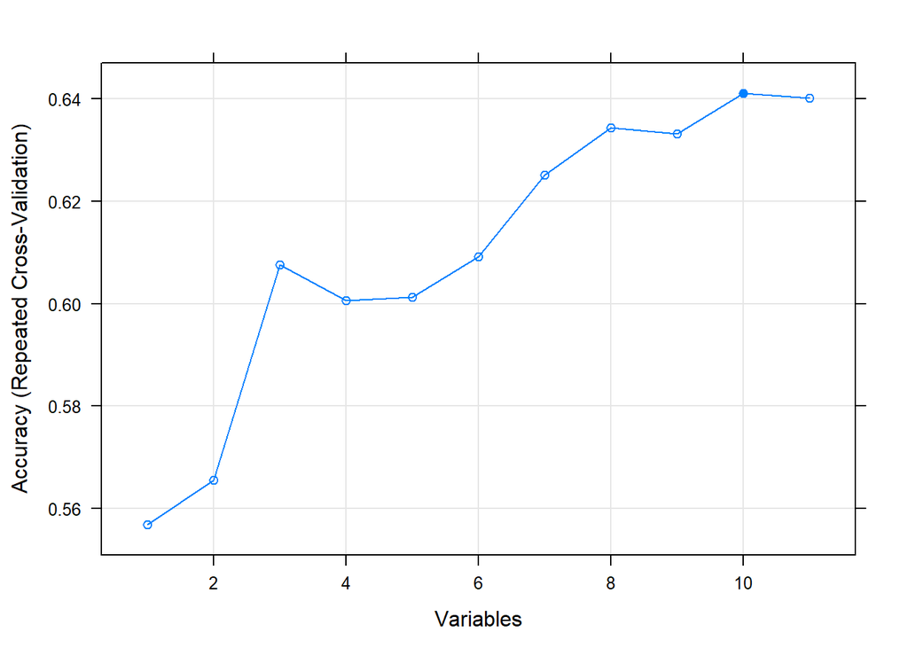

The variables selected were:

```
##  [1] "district"        "origin"          "alert_month"     "tavg15d"
##  [5] "alert_period"    "tavg"            "village_area"    "farming_area"
##  [9] "vegetation_area" "duration"
```

# 5 Exploratory Data Analysis

# 6 Prediction Models

Predictive modeling is a probabilistic process that allows us to forecast outcomes, on the basis of some predictors. These predictors are basically features that come into play when deciding the final result, i.e. the outcome of the model.

## 6.1 Distance-based Approach

### 6.1.1 K-Nearest Neighbor

## 6.2 Probabilistic Approach

Discriminant analysis is used to predict the probability of belonging to a given class (or category) based on one or multiple predictor variables. It works with continuous and/or categorical predictor variables.

Compared to logistic regression, the discriminant analysis is more suitable for predicting the category of an observation in the situation where the outcome variable contains more than two classes. Additionally, it’s more stable than the logistic regression for multi-class classification problems.

## 6.3 Mathematical Formulae

Linear discriminant analysis (LDA): Uses linear combinations of predictors to predict the class of a given observation. Assumes that the predictor variables (p) are normally distributed and the classes have identical variances (for univariate analysis, p = 1) or identical covariance matrices (for multivariate analysis, p > 1).

The LDA algorithm starts by finding directions that maximize the separation between classes, then use these directions to predict the class of individuals. These directions, called linear discriminants, are a linear combinations of predictor variables.

LDA assumes that predictors are normally distributed (Gaussian distribution) and that the different classes have class-specific means and equal variance/covariance.

Before performing LDA, consider:

Inspecting the univariate distributions of each variable and make sure that they are normally distribute. If not, you can transform them using log and root for exponential distributions and Box-Cox for skewed distributions. removing outliers from your data and standardize the variables to make their scale comparable. The linear discriminant analysis can be easily computed using the function lda() [MASS package].

## 6.4 Logical Approaches

## 6.5 Optimization Approaches

## 6.6 Ensemble Approaches

## 6.7 Assess Models

# 7 Conclusions

# 8 References